# Presentación personal

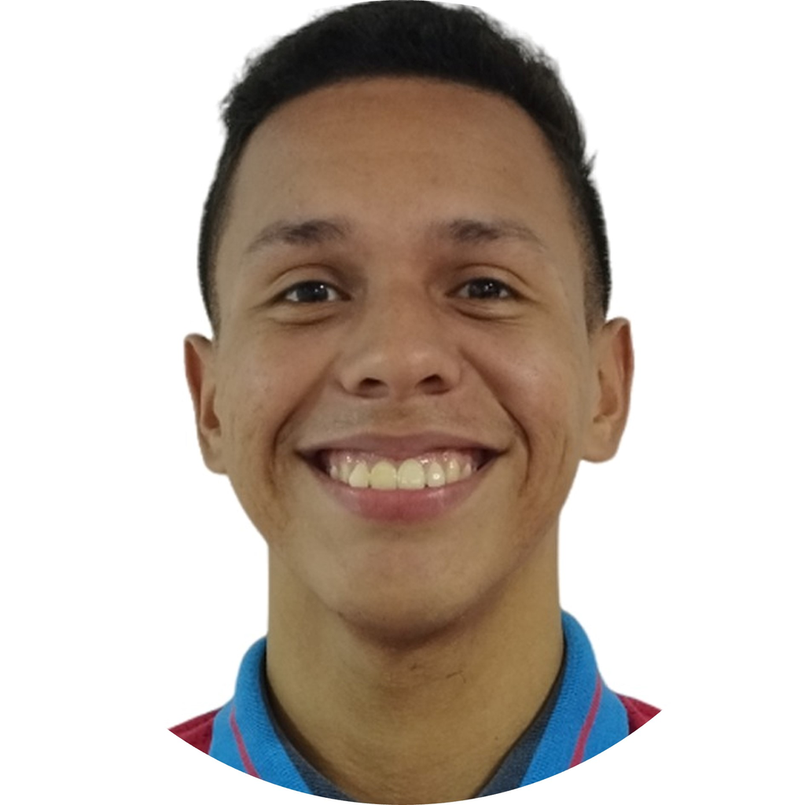

**Sebastián A. Herazo Pretelt**

El propósito de esta presentación es dar a conocer mi trayectoria académica y profesional, mi perfil, destacando mis competencias, logros y experiencias, así como mis objetivos a corto y mediano plazo.

## Formación académica

- Pregrado en Ingeniería Industrial, Corporación Universitaria Americana. Graduado en 2024.
- Maestría en Ingeniería Industrial, Universidad del Norte (07/2024 - Actual).

## Perfil

Ingeniero Industrial, con énfasis en gestión de operaciones y análisis de datos. Poseo altas habilidades en herramientas informáticas y adaptación a nuevas tecnologías. Tengo experiencia en proyectos de investigación y amplios conocimientos en razonamiento cuantitativo, modelación matemática y optimización.

## Habilidades Técnicas y Blandas

### Habilidades Técnicas

**Excel**

*Experiencia en análisis de datos, creación de dashboards, y automatización de procesos.*

**Power BI**

*Desarrollo de reportes interactivos y visualizaciones.*

**Python**

*Aplicaciones básicas en análisis de datos y optimización.*

**R**

*Competencias en estadística y análisis de datos.*

### Habilidades Blandas

- **Comunicación Efectiva:** Capacidad para transmitir ideas de manera clara y efectiva en entornos multidisciplinarios.
- **Trabajo en Equipo:** Experiencia colaborando con equipos diversos, tanto en proyectos académicos como profesionales.
- **Liderazgo:** Habilidad para dirigir y coordinar equipos en la ejecución de proyectos.
- **Adaptabilidad:** Facilidad para aprender y aplicar nuevas tecnologías y metodologías en el trabajo.

## Experiencia profesional

En este apartado presento la experiencia que he tenido, tanto laboral como investigativa.

### Experiencia laboral

Con este ítem me refiero a la experiencia que no ha tenido ninguna relación propia con proyectos de investigación.

- **Auxiliar de Mercadeo Virtual**, Corporación Universitaria Americana (09/2022 - 03/2023).  
  *Asesoría comercial y servicio al cliente de los programas de posgrados virtuales. Gestión CRM.*
- **Auxiliar de Cumplimiento**, Comercializadora de Servicios del Atlántico (04/2023 - 10/2023).  
  *Analista transaccional. Gestión con Excel, Power BI.*
  - **Logro Clave:** Desarrollé un sistema de reportes en Power BI que mejoró la visibilidad de los indicadores clave de rendimiento (KPI) en un 40%.

### Experiencia investigativa

- **Co-investigador de proyectos de Investigación**, Corporación Universitaria Americana (10/2023 - Actual).  
  *Apoyo a investigadores principales en los proyectos.*
  - **Contribución Significativa:** Lidero el análisis de datos para un estudio sobre optimización en el sector servicios, cuyos resultados esperan ser presentados en conferencias internacionales.
- **Semillerista de GOTI**, Corporación Universitaria Americana (09/2021 - Actual).  
  *Participación activa en el semillero Gestión de Operaciones, Tecnología e Innovación, desarrollando proyectos, asistiendo a eventos científicos nacionales e internacionales.*
  - **Logro Clave:** Contribución a proyectos que han sido divulgados en diferentes eventos científicos, destacando la aplicación de técnicas avanzadas de optimización en el sector retail.

## Proyectos Destacados

### Proyecto de Flexibilidad Laboral integrada en el Sector Retail

- **Descripción:** Desarrollo de un modelo de planificación de la fuerza laboral que integra cuatro esquemas de flexibilidad.
- **Resultados:** La ejecución del modelo mostró significativos beneficios, alcanzando consistentemente ahorros monetarios de al menos un 65%. Además, se evidenció la robustez de la estrategia propuesta para abordar el desafiante problema de planificación de la fuerza laboral en el sector de servicios. Dicho proyecto fue reconocido como Trabajo de Grado Laureado en 2024.

### Proyecto de Programación semanal de turnos

- **Descripción:** Propuesta de un modelo de optimización para la planificación semanal de los turnos de trabajo de los empleados para un horizonte de planificación de 52 semanas (i.e., un año).
- **Resultados:** Los hallazgos fueron presentados en el XXI Congreso Latino-Iberoamericano de Investigación Operativa, donde obtuvieron una respuesta positiva de la comunidad académica.

## Logros y reconocimientos

- [**Destacada labor y contribución al ámbito de la Investigación**](https://1drv.ms/b/c/7937790d2e6d2340/Efo-pWERj2pHoUVhwnQ6ozABd_INUqxZpQNkJP4rlmA8cw?e=Q7g8AY), Corporación Universitaria Americana (05/2024).  
  *En medio del II Encuentro de Semilleros de Investigación Americana se me ha reconocido como ‘distinguido semillerista que ha continuado en la Institución cultivando su talento y recogiendo frutos como egresado.’*
- [**Distinción Honorífica de Trabajo de Grado Laureado**](https://1drv.ms/b/c/7937790d2e6d2340/Ef49rAAWP39OmvRGe61xsREBWdaSDpDU-J-DwNI3eaDtUA?e=0988MS), Corporación Universitaria Americana (04/2024).  
  *Mi trabajo de grado titulado ‘Esquemas integrados de flexibilidad para la planificación de la fuerza laboral en el sector de servicios: una estrategia aplicada en la industria del retail’ fue exaltado públicamente como Laureado.*
- [**Participación como ponente en CLAIO 2022, Buenos Aires, Argentina**](https://1drv.ms/b/c/7937790d2e6d2340/EdKwdsGEjSxCpPkq6_lvCgYBceEOV46Vi7XhEuTaCEnFqw?e=AU2b5E) (12/2022).  
  *He presentado una ponencia en el XXI Congreso Latino-Iberoamericano de Investigación Operativa. La ponencia se tituló ‘Annualized hours contract with flexible working day: A personnel planning approach’, la cual era fruto de un proyecto de flexibilidad laboral desarrollado en el semillero al que pertenezco.*
- **Becario Jóvenes Becarios Por Un Nuevo Puerto Colombia** (01/2019 - 12/2023).  
  *Fui seleccionado como becario del proyecto promocionado por la Alcaldía de Puerto Colombia, en el que mantuve el promedio exigido para cubrir la matrícula, haciéndome merecedor de exoneración del 100% del valor durante mi carrera profesional.*

## Objetivos Profesionales

A corto plazo, deseo seguir profundizando en la gestión de operaciones, análisis de datos y la optimización. Para ello he iniciado la Maestría en Ingeniería Industrial de la Universidad del Norte, que me permitirá desarrollar competencias avanzadas en estas áreas.

A mediano-largo plazo, aspiro a liderar proyectos innovadores que impulsen la eficiencia en diversos sectores, así como iniciar mi doctorado en un área relacionada con la optimización y la gestión de operaciones. Mi objetivo final es contribuir al desarrollo de soluciones sostenibles y eficientes en la industria.

## Intereses Personales

- **Lectura:** Disfruto leer sobre diferentes temáticas como crecimiento personal, poesía.
- **Aprendizaje continuo:** Busco siempre aprender nuevas herramientas, técnicas y conocimientos para mantenerme al día en mi campo profesional y personal. Esto incluye la participación en cursos, talleres, y la lectura de publicaciones relevantes para asegurarme de estar al tanto de las últimas tendencias y avances en mi área de interés.
- **Actividad física:** Entreno en el gimnasio como parte de mi rutina de bienestar.
- **Viajes:** Me gusta explorar nuevas culturas y aprender de diferentes enfoques en la resolución de problemas.

## Contacto

- ing.sebastianherazo@gmail.com
- 3023003683
- LinkedIn
- [Orcid](https://orcid.org/0009-0007-4463-3239)

Gracias por su atención y por la oportunidad de compartir mi perfil profesional con ustedes.